# HW 10: Paired comparison models

Shane Fuller

# Preliminary notes for doing HW

1. All files should be knit and compiled using R Markdown. Knit early and often! I do not recommend waiting until the end of the HW to knit.
2. All questions should be answered completely, and, wherever applicable, code should be included.
3. If you work with a partner or group, please write the names of your teammates.
4. Copying and pasting of code is a violation of the Skidmore honor code

## Overview

In this HW, we are going to implement and analyze the results of Bradley-Terry models.

We are going to use a data set that comes with the `BradleyTerry2` package called **icehockey**.

```r
library(tidyverse)
library(BradleyTerry2)
head(icehockey)
```

```
##       date         visitor v_goals        opponent o_goals conference
## 1 20091008      Quinnipiac       4      Ohio State       2         NC
## 2 20091008      Rensselaer       2   Massachusetts       5         NC
## 3 20091009       Air Force       1   Bemidji State       3         NC
## 4 20091009 Alab-Huntsville       3      Notre Dame       2         NC
## 5 20091009            Army       4  Nebraska-Omaha       6         NC
## 6 20091009   Bowling Green       2 Minnesota State       3         NC
##   result home.ice
## 1      1     TRUE
## 2      0     TRUE
## 3      0     TRUE
## 4      1     TRUE
## 5      0     TRUE
## 6      0     TRUE
```

```r
summary(icehockey)
```

```
##       date                   visitor       v_goals
##  Min.   :20091008   Brown        : 23   Min.   : 0.000
##  1st Qu.:20091114   Michigan     : 23   1st Qu.: 1.000
##  Median :20100108   Connecticut  : 22   Median : 3.000
##  Mean   :20095981   Lake Superior: 22   Mean   : 2.633
##  3rd Qu.:20100212   Mercyhurst   : 22   3rd Qu.: 4.000
##  Max.   :20100320   Clarkson     : 21   Max.   :10.000
##                     (Other)      :950
##               opponent      o_goals       conference     result
##  Denver           : 23   Min.   : 0.000   AH:140     Min.   :0.0000
##  Minnesota Duluth : 23   1st Qu.: 2.000   CC:168     1st Qu.:0.0000
##  North Dakota     : 23   Median : 3.000   CH: 36     Median :0.0000
##  Boston University: 22   Mean   : 3.231   EC:132     Mean   :0.3957
##  Ferris State     : 22   3rd Qu.: 4.000   HE:135     3rd Qu.:1.0000
##  Miami            : 22   Max.   :11.000   NC:332     Max.   :1.0000
##  (Other)          :948                    WC:140
##   home.ice
##  Mode :logical
##  FALSE:69
##  TRUE :1014
##
##
##
##
```

```r
dim(icehockey)
```

```
## [1] 1083    8
```

The data contain 1083 games from the 2009-10 NCAA college hockey season. More of the variables are self-explanatory, but there are a few that are worth pointing out.

First, game results are coded as `0`, `0.5`, or `1`.

## Exploratory analysis

1. Make a histogram identifying the total number of goals in each game (you’ll have to make this variable), faceted by conference. Then calculate the mean total goals per game for each conference. Compare the centers, shapes, and spread of this variable (total number of goals scored) between the conferences.

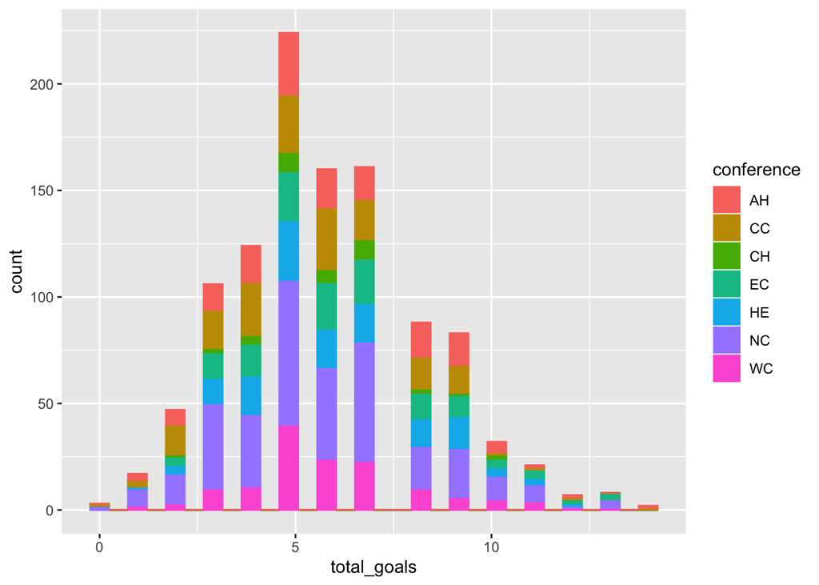

```r
icehockey <- icehockey %>%
  mutate(total_goals = v_goals + o_goals)

ggplot(icehockey, aes(x=total_goals, fill=conference, color=conference)) + geom_histogram()
```

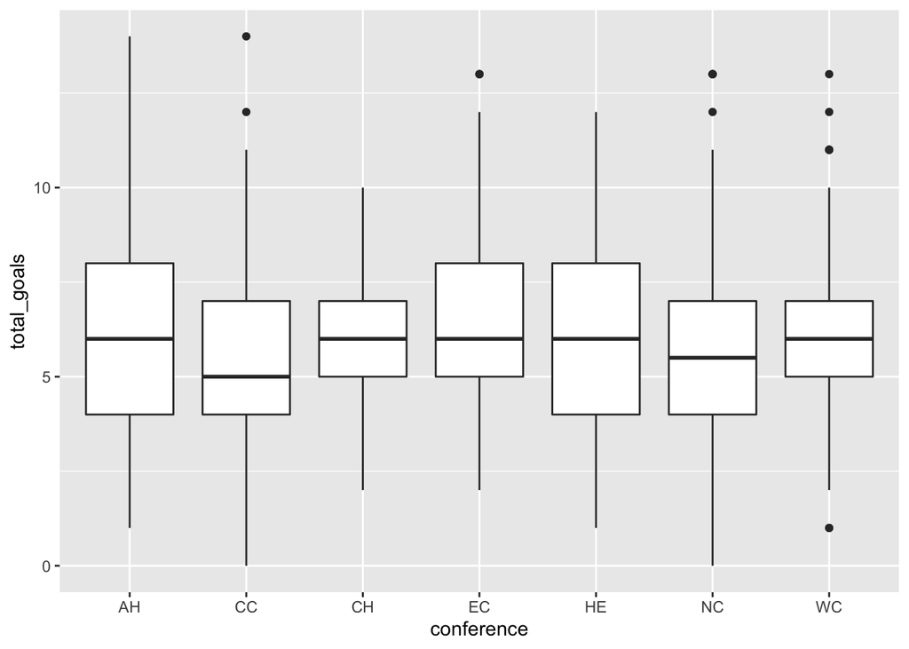

```r
ggplot(icehockey, aes(x=conference, y=total_goals)) + geom_boxplot()
```

```r
average_goals_data <- icehockey %>%
  group_by(conference) %>%
  summarise(average_goals = sum(total_goals) / n(), total_games = n()) %>%
  arrange(-average_goals)

average_goals_data
```

```
## # A tibble: 7 x 3
##   conference average_goals total_games
##   <fct>              <dbl>       <int>
## 1 EC                  6.30         132
## 2 HE                  6.04         135
## 3 WC                  6            140
## 4 AH                  5.92         140
## 5 CH                  5.92          36
## 6 NC                  5.76         332
## 7 CC                  5.42         168
```

2. Look only at the games not played at neutral sites (`home.ice == FALSE`). How many more goals per game does the home team score, on average, than the away team?

```r
icehockey_away <- icehockey %>%
  ungroup(conference) %>%
  filter(home.ice == FALSE) %>%
  summarise(average_goals = sum(total_goals) / n(), total_games = n()) %>%
  arrange(-average_goals)

icehockey_home <- icehockey %>%
  ungroup(conference) %>%
  filter(home.ice == TRUE) %>%
  summarise(average_goals = sum(total_goals) / n(), total_games = n()) %>%
  arrange(-average_goals)

icehockey_away
```

```
##   average_goals total_games
## 1      5.565217          69
```

```r
icehockey_home
```

```
##   average_goals total_games
## 1      5.883629        1014
```

*It appears that the average goals for teams playing away from home ice is 5.565217, while the average goals for teams playing on a home ice is 5.883629. This means that games that are played at a neutral site to to have 0.318412 less goals than games that are not played on neutral ice.*

## Fitting the standard Bradley-Terry model

First, let’s start by fitting the standard BTM model on this data set.

```r
standardBT <- BTm(outcome = result,
    player1 = visitor, player2 = opponent,
    id = "team", data = icehockey)
library(broom)
tidy(standardBT)
```

```
## # A tibble: 57 x 5
##    term                  estimate std.error statistic   p.value
##    <chr>                    <dbl>     <dbl>     <dbl>     <dbl>
##  1 teamAir Force           -1.41      0.656    -2.15  0.0312
##  2 teamAlab-Huntsville     -0.683     0.605    -1.13  0.259
##  3 teamAmerican Int'l      -2.93      0.712    -4.12  0.0000384
##  4 teamAlaska               0.683     0.557     1.23  0.220
##  5 teamArmy                -1.89      0.662    -2.86  0.00428
##  6 teamBoston College       1.17      0.613     1.91  0.0565
##  7 teamBowling Green       -0.896     0.606    -1.48  0.139
##  8 teamBrown               -0.759     0.602    -1.26  0.207
##  9 teamBemidji State        0.683     0.580     1.18  0.239
## 10 teamBoston University    0.455     0.597     0.763 0.445
## # … with 47 more rows
```

```r
abilities <- exp(BTabilities(standardBT))
abilities <- data.frame(abilities)
abilities$Team <- rownames(BTabilities(standardBT))
abilities %>%
  arrange(ability)
```

```
##       ability     s.e.              Team
## 1  0.05331104 2.038340    American Int'l
## 2  0.06718922 1.996966       Connecticut
## 3  0.13074205 1.946388           Bentley
## 4  0.14667207 1.936968        Holy Cross
## 5  0.15074874 1.939288              Army
## 6  0.15856632 1.919658        Mercyhurst
## 7  0.21810439 1.926512          Canisius
## 8  0.24328805 1.927167         Air Force
## 9  0.32960441 1.818478          Clarkson
## 10 0.34582066 1.915711      Sacred Heart
## 11 0.38679284 1.851741         Dartmouth
## 12 0.38955760 1.855903           Harvard
## 13 0.40802160 1.833305     Bowling Green
## 14 0.43385757 1.795889     Michigan Tech
```

[output cut: 44 more lines]

3. Using the output, estimate the probability of Boston College beating Army.

*The probability of Boston College beating Army is about 95.5%.*

4. Identify the biggest mismatch in teams, and what the probability is of the worse team winning that game.

*The greatest mismatch between teams would be between Denver and American International, and the probability that the team would be 0.01.*

## BTM with home ice included.

Let’s return to our original equation, and add in a home advantage term.

**Original**: log(Odds ($i$ beats $j$)) = $\lambda_i$ - $\lambda_j$ where $\lambda_i = log(\alpha_i)$ and $\lambda_j = log(\alpha_j)$

**Home advantage**: log(Odds ($i$ beats $j$ in a home game for $i$)) = $\lambda_i$ - $\lambda_j$ where $\lambda_i = log(\alpha_i + \omega_i)$ and $\lambda_j = log(\alpha_j)$, where $\omega_i$ is an indicator for the game being played at team $i$. *Note*: If the game is played at a neutral site, $\omega_i = 0$.

Here’s the home ice model

```r
homeBT <- BTm(result,
               data.frame(team = visitor, home.ice = 0),
               data.frame(team = opponent, home.ice = home.ice),
               ~ team + home.ice,
               id = "team", data = icehockey)

tidy(homeBT)
tidy(homeBT) %>% tail()
head(BTabilities(homeBT), 10)
```

[output not shown]

5. Assuming team strength is held constant, what are the increased odds that the home team wins?

6. Estimate the probability that Boston College beating Army in
- a game with no home-ice advantage (this should be similar to your answer to question 3).
- a game with Boston College having home advantage
- a game with Army having home advantage

```r
exp(1.3303922)/(exp(1.3303922)+exp(-1.5974521))
```

```
## [1] 0.9492058
```

```r
exp(1.3303922+0.4028986)/(exp(1.3303922+0.4028986)+exp(-1.5974521))
```

```
## [1] 0.9654685
```

```r
exp(1.3303922)/(exp(1.3303922)+exp(-1.5974521+0.4028986))
```

```
## [1] 0.9258722
```

*The probability of Boston College beating Army on neutral ice would be 94.9%. The probability of Boston College beating Army having home advantage would be 96.5%. The probability of Boston College beating Army with Army having home advantage would be 92.6%.*

7. Use your answers to the previous question to confirm that the odds of a home win in hockey are about 1.496 times higher than a road team win, assuming team strength is fixed.

```r
0.9492058/(1-0.9492058)
```

```
## [1] 18.68729
```

```r
0.9654685/(1-0.9654685)
```

```
## [1] 27.95907
```

```r
0.9258722/(1-0.9258722)
```

```
## [1] 12.49022
```

```r
27.95907/18.68729
```

```
## [1] 1.496154
```

```r
18.68729/12.49022
```

```
## [1] 1.496154
```

*If we assume that team strength is fixed, lookng at the previous answers, if we take the probabilities for both and relate these to neutral ice probabilities, the answers come out to be about 1.496. Therefore, this would suggest that the odds of a home win in hockey are about 1.496 times higher than a road team win.*